# Progress Memo 2

Final Project  
Data Science 1 with R (STAT 301-1)

Author

Nina Gupta

Published

November 24, 2024

**Github Repo Link**

[Nina’s Final Project Memo 2 Github Repo (ninag0104)](https://github.com/stat301-1-2024-fall/final-project-1-ninag0104)

## Data Source Summary

[Chicago Crime Data](https://www.chicago.gov/city/en/dataset/crime.html)

As a reminder, the data source I chose is the City of Chicago’s[^1] “Chicago Crime Data”, presenting data from one year prior to the current date, minus the last 7 days. The link below provides more information on the source, data reliability, and variable meanings.

<sup>1</sup> data collected by Chicago Police Department

[Description of Chicago Crime Data](https://data.cityofchicago.org/Public-Safety/Crimes-One-year-prior-to-present/x2n5-8w5q/about_data)

## Cleaning Data

To clean the data, I started in Progress Memo 1 by converting the variable names to all lowercase and adding underscores for better readability.

Considering I am exploring the relationship between location and crime committed, I decided to remove some identification variables I am not considering/that will not impact the analysis needed to answer my research question, including iucr[^2] and fbi_cd[^3].

<sup>2</sup> Illinois Uniform Reporting Code

<sup>3</sup> FBI’s classification of crime

Since I’ve already explored the missingness in Progress Memo 1 and determined that all missing data relates to location, I’ve decided to filter out the missing data so that it doesn’t negatively impact my analysis.

Table 1. Missingness of Specific Variables in Chicago Crime Data (from Progress Memo 1)

| variable | missing_count |
| --- | --- |
| missing_location | 105 |
| missing_location_description | 1062 |
| missing_longitude | 105 |
| missing_latitude | 105 |
| missing_x_coordinate | 105 |
| missing_y_coordinate | 105 |
| missing_total | 1587 |

## EDA

After cleaning up my data by standardizing it, removing unnecessary variables, and removing missing values, I have a dataset called chicago_crimes_clean and am ready to complete EDA. To start, my initial research question is: **What is the correlation between types of crimes committed and location in the city of Chicago?**

## Univariate Analysis

To begin, I determined the top 20 locations with the most crimes committed. I did the same for the top 20 locations with the least number of crimes committed.

Table 2. Top 20 Locations with Most Crimes Committed

| location_description | n |
| --- | --- |
| STREET | 71142 |
| APARTMENT | 48466 |
| RESIDENCE | 30212 |
| SIDEWALK | 13679 |
| SMALL RETAIL STORE | 9438 |
| PARKING LOT / GARAGE (NON RESIDENTIAL) | 8960 |
| RESTAURANT | 6169 |
| ALLEY | 6072 |
| DEPARTMENT STORE | 5543 |
| OTHER (SPECIFY) | 4070 |
| COMMERCIAL / BUSINESS OFFICE | 3825 |
| VEHICLE NON-COMMERCIAL | 3716 |
| RESIDENCE - PORCH / HALLWAY | 3157 |
| GAS STATION | 3092 |
| RESIDENCE - YARD (FRONT / BACK) | 2662 |
| GROCERY FOOD STORE | 2635 |
| RESIDENCE - GARAGE | 2537 |
| BAR OR TAVERN | 1976 |
| PARK PROPERTY | 1874 |
| CONVENIENCE STORE | 1870 |

Table 3. Top 20 Locations with Least Crimes Committed

| location_description | n |
| --- | --- |
| BARBER SHOP/BEAUTY SALON | 1 |
| BASEMENT | 1 |
| CTA “L” TRAIN | 1 |
| FARM | 1 |
| GANGWAY | 1 |
| GARAGE | 1 |
| HOTEL | 1 |
| LIQUOR STORE | 1 |
| NEWSSTAND | 1 |
| OFFICE | 1 |
| RAILROAD PROPERTY | 1 |
| SAVINGS AND LOAN | 1 |
| SCHOOL YARD | 1 |
| STAIRWELL | 1 |
| TAVERN | 1 |
| VEHICLE - COMMERCIAL: ENTERTAINMENT / PARTY BUS | 1 |
| HALLWAY | 2 |
| KENNEL | 2 |
| CHA HALLWAY | 3 |
| HOSPITAL | 3 |

In addition, I calculated the top 10 crimes that are committed in the city of Chicago.

Table 4. Top 10 Crimes Committed in Chicago

| primary_description | n |
| --- | --- |
| THEFT | 59995 |
| BATTERY | 45616 |
| CRIMINAL DAMAGE | 28781 |
| ASSAULT | 23416 |
| MOTOR VEHICLE THEFT | 23097 |
| OTHER OFFENSE | 16707 |
| DECEPTIVE PRACTICE | 13996 |
| ROBBERY | 9733 |
| WEAPONS VIOLATION | 8118 |
| BURGLARY | 8042 |

From my univariate analysis, I am able to deduce that the most common crimes committed in Chicago are theft, battery, and criminal damage. Crimes are most likely to occur on the street, followed by apartments and residences.

## Bivariate Analysis

[figure not shown]

[figure not shown]

[figure not shown]

[figure not shown]

## Use of AI

PROGRESS MEMO 1:

This dataset includes 257,912 observations and 17 variables containing both numerical (location (coordinates), date, case number, etc.) and categorical variables (primary description (type of crime), secondary description (weapons used), block where the crime was committed, etc). There are 6 numerical variables and 11 categorical. With the amount of data, there are many relationships to be explored in this dataset.

I’ve explored the data using visuals that are in the “References” section of this document[^4]

<sup>4</sup> Located at the bottom of the document

## Why this data

I chose this data because I was curious to learn more about crime rates in Chicago and explore trends within the dataset, also considering we are located close to the city.

Although I am still narrowing it down, I am interested exploring the correlation between types of crimes committed and another variable, possibly location or date of occurrence of the crime in Chicago. Since I am sure I want to explore the type of crime vs another variable, in Figure 1 I explored the distribution of the types of crimes committed in Chicago.

## Data quality & complexity check

This data was collected by the City of Chicago during a specific time period[^5]. Data is extracted from the Chicago Police Department’s CLEAR (Citizen Law Enforcement Analysis and Reporting) system and is a reputable source of information, other than room for bias of police officers who collected the data. This is something I will have to note while making conclusions about the data.

<sup>5</sup> one year prior to current date minus the past 7 days

<sup>6</sup> as seen in Figure 1

This dataset is updated daily, Tuesday through Sunday. This dataset is complex considering the number of variables and distribution of types of crime[^6] and that there are 6 variables with missing data, as shown in Figure 2 and Table 1.

## Potential data issues

One issue with the data mentioned earlier is that the police officers who collected it are subject to bias, which could be reflected in the data by representing potentially harmful stereotypes and generalizations. Considering crime is a complex and sensitive topic to explore, many incorrect assumptions can be made without proper consideration of the influence of bias.

This indicates it may be ideal to explore a variable other than location, such as date or number of arrests, and its relation to the type of crime. In Figure 1, I explored the distribution of the types of crimes using the primary_description variable.

## References

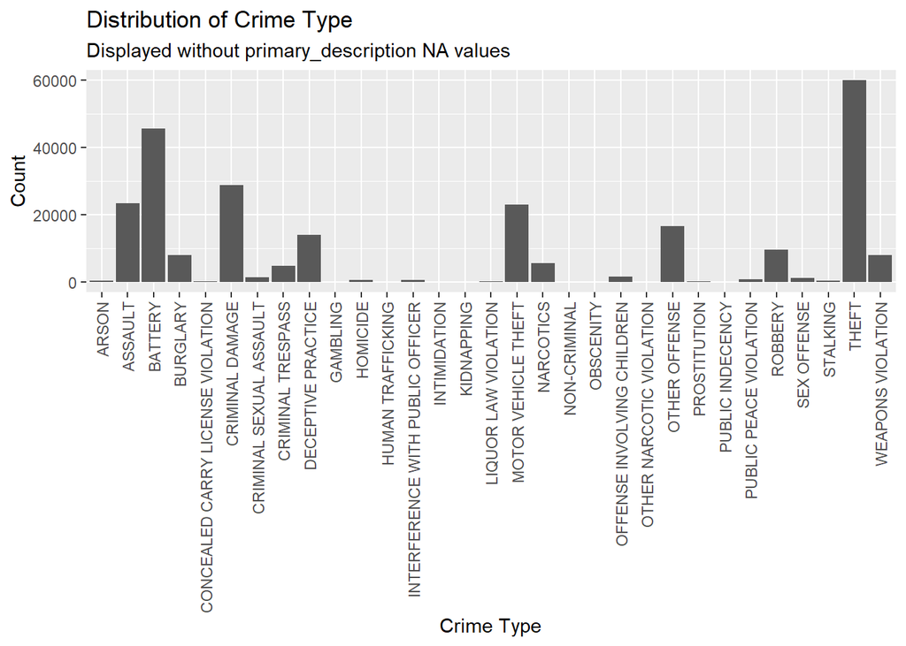

Figure 1: Distribution of Crime Type

Figure 1

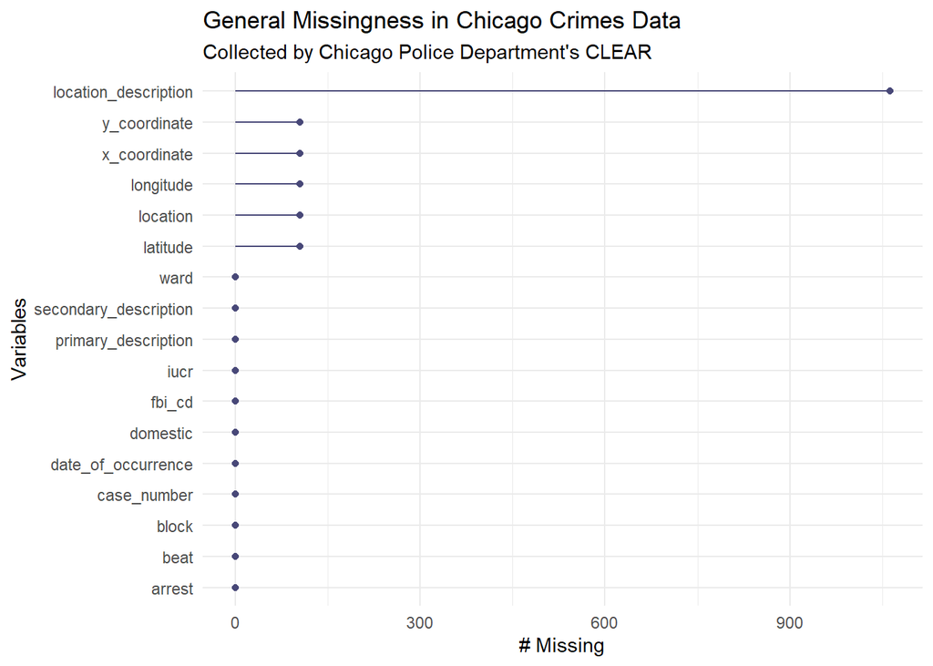

Figure 2: General Missingness in Chicago Crimes Data

Figure 2